# High School Seniors 2

```r
library(mosaic)
library(DT)
library(pander)
library(car)
library(tidyverse)

# Read in the data
HighSchoolSeniors <- read.csv("../../Data/HighSchoolSeniors.csv", header=TRUE)
```

```r
HSSA <- HighSchoolSeniors %>%
  filter(!is.na(Score_in_memory_game), !is.na(Gender), Favourite_physical_activity %in% c("Walking/Hiking", "Athletics", "Basketball")) |>
  mutate(Score_in_memory_game = as.numeric(Score_in_memory_game), Gender = as.factor(Gender), Favourite_physical_activity = as.factor(Favourite_physical_activity)) |>
  na.omit(Score_in_memory_game)
```

### Intro/Context

This data set was collected after a questionnaire was handed out to high school students around the US. There were different types of questions that helped to gather the information that will be used for this analysis. The information used for this test will be the memory score that students got while taking the memory test question and their favorite physical activity (Walking/Hiking, Athletics, Basketball).

The level of significance for this analysis will be σ=0.05

### Three sets of Ho/Ha (Two-way ANOVA)

#### Hypotheses Gender

Does gender affect the memory test score?

$$H_0: \mu_\text {Male} = \mu_\text{Female} = \mu$$

$$H_a: \mu_\text {Male} \neq \mu_\text{Female}$$

#### Hypotheses Favourite Physical Activity

Does the type of physical activity affect the memory test score?

$$H_0: \mu_\text {Walking/Hiking} = \mu_\text {Athletics} = \mu_\text{Basketball} = \mu$$

$$H_a: \mu_i \neq \mu \text { for at least one i ∈{1=Walking/Hiking, 2=Athletics, 3=Basketball}}$$

#### Hypotheses about the interation of Gender and Favorite Physical Activity

Does the effect of the Favourite Physical Activity change for the different types of Gender? (Does the effect of Gender change for different Favourite Physical Activities?) In other words, is there an interaction between Gender and Favourite Physical Activity?

$$H_0: \text{The effect of the Favourite Physical Activity is the smae for all types of Gender}$$
$$H_a: \text{The effect of the Favourite Physical Activity is not the same for all types of Gender}$$

### Two-way ANOVA test

To perform the analysis we compute the following Two-way ANOVA.

```r
hssa.aov <- aov(Score_in_memory_game ~ Favourite_physical_activity + Gender + Favourite_physical_activity:Gender, data=HSSA)
summary(hssa.aov) %>% pander()
```

Analysis of Variance Model

|  | Df | Sum Sq | Mean Sq | F value | Pr(>F) |
| --- | --- | --- | --- | --- | --- |
| **Favourite_physical_activity** | 2 | 169.4 | 84.7 | 0.4936 | 0.6122 |
| **Gender** | 1 | 1.754 | 1.754 | 0.01022 | 0.9197 |
| **Favourite_physical_activity:Gender** | 2 | 19.26 | 9.628 | 0.0561 | 0.9455 |
| **Residuals** | 86 | 14758 | 171.6 | NA | NA |

The ANOVA table summary above compiles the three different p-values that we obtained after computing the test for each set of hypotheses. The conclusions are that Gender is not a significant factor (p = 0.9197), the Favourite Physical Activity does not have a significant effect on the memory test score (p = 0.6122), and the effect of the physical activity does not depend on the Gender because the interaction term is also insignificant (p = 0.9455)

### Check the requirements for the Two-way ANOVA tst

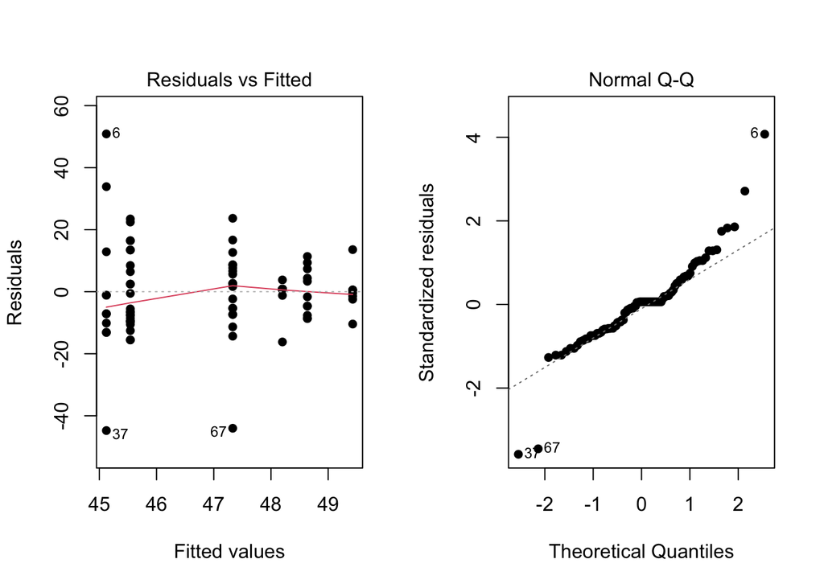

```r
par(mfrow=c(1,2))
plot(hssa.aov, which=1:2, pch=16)
```

The appropriateness of the ANOVA test is questionable as it is shown in the two plots below. The Q-Q plot (Graph on the right) does not look normal so it’s not completely error term satisfied, and it has some outliers as we see in points 37, 67, and 6 that show a few abnormalities. The residual vs fitted values plot on the left shows that the spread of the set of points seems to be smaller as the groups move forward. The change in variance is not substantial enough to discard an ANOVA test, so the result of this analysis can be assumed to be valid.

### Graphical Summaries

Since we have three sets of hypotheses for this analysis, then three different graphical summaries will be analyzed for each on of the hypotheses below

#### Gender

This first graph is to show the insignificance of the Gender influencing the score in th memory test. The average number in the memory test score does not seem to be affected by the different genders. However, there was a small different on the average memory test score, Females got 0.06 higher scores than Males. Since the P-value for gender was p-value=0.9197, we can conclude that, we don’t have statistical evidence if there is a difference on average in the memory test score by Gender.

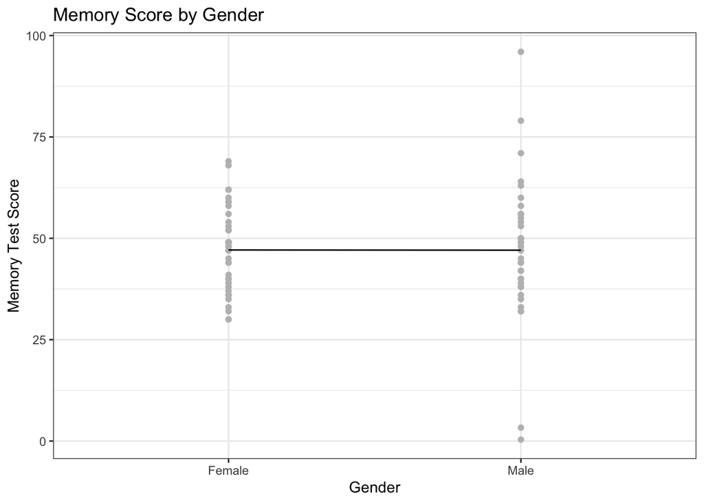

```r
ggplot(HSSA, aes(x=Gender, y=Score_in_memory_game, group=1)) +
  geom_point(color="gray") +
  stat_summary(fun="mean", geom="line") +
  labs(title="Memory Score by Gender", x="Gender", y="Memory Test Score") +
  theme_bw()
```

```r
HSSA %>%
  group_by(Gender) %>%
  summarise(`Mean Score in Memory Game`=mean(Score_in_memory_game)) %>%
  pander(caption="Mean Score in Memory Game according to Gender")
```

Mean Score in Memory Game according to Gender

| Gender | Mean Score in Memory Game |
| --- | --- |
| Female | 47.13 |
| Male | 47.07 |

#### Favourite Physical Activity

The second graph shows that in general, there is no a significant change on the memory test score depending on the physical activity. However, there is a small decrease on the memory test score as we move from left (Athletics) to right (Waking/Hiking) The graph shows that on average the highest memory test score goes for Athletics Score = 48.52, moving forward to Basketball with score = 47.81, and finally Walking/Hiking with the lowest score of 45.41. Whether or not there is an advantage on memory recall of Athletics over Basketball and Walking/Hiking in not clear, that is why further testing would be required to find a conclusion.

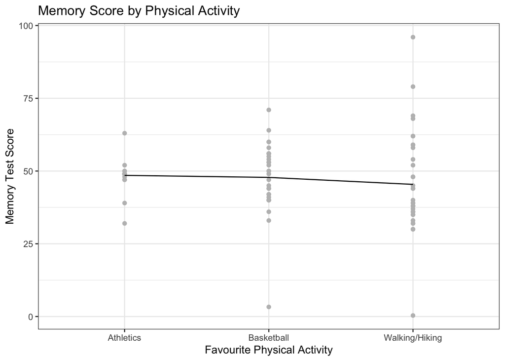

```r
ggplot(HSSA, aes(x=Favourite_physical_activity, y=Score_in_memory_game, group=1)) +
  geom_point(color="gray") +
  stat_summary(fun="mean", geom="line") +
  labs(title="Memory Score by Physical Activity", x="Favourite Physical Activity", y="Memory Test Score") +
  theme_bw()
```

```r
HSSA %>%
  group_by(Favourite_physical_activity) %>%
  summarise(`Mean Score in Memory Game`=mean(Score_in_memory_game)) %>%
  pander(caption="Mean Score in Memory Game according to Favourite Physical Activity")
```

Mean Score in Memory Game according to Favourite Physical Activity

| Favourite_physical_activity | Mean Score in Memory Game |
| --- | --- |
| Athletics | 48.52 |
| Basketball | 47.81 |
| Walking/Hiking | 45.41 |

#### Favourite Physical Activity Depending on the Gender

As mentioned before, the gender does not have a high impact on the memory test score on average, however there are small difference for each gender by the different physical activities. The largest difference by gender on the memory score is for Basketball where Females had on average 1.31 higher score than Males (Females=48.64, Males=47.33, 48.64-47.33 = 1.31), however, the overall highest average score is for Males whose favorite physical activity is Athletics with an average score of 49.43 and for Females of 48.2, giving a difference of 1.23 higher on avergae for Males.

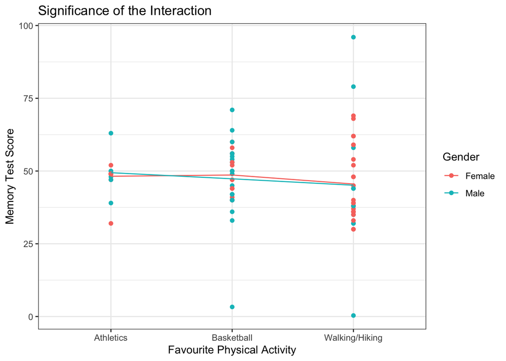

```r
ggplot(HSSA, aes(x=Favourite_physical_activity, y=Score_in_memory_game, group=Gender, color=Gender)) +
  geom_point() +
  stat_summary(fun="mean", geom="line") +
  labs(title="Significance of the Interaction", x="Favourite Physical Activity", y="Memory Test Score") +
  theme_bw()
```

```r
HSSA %>%
  group_by(Gender, Favourite_physical_activity) %>%
  summarise(`Mean Score in Memory Game`= mean(Score_in_memory_game), .groups="drop") %>%
  pander(caption="Mean Score in Memory Game according to Gender (M, F) and Favourite Physical Activity (Walking/Hiking, Athletics, Basketball)")
```

Mean Score in Memory Game according to Gender (M, F) and Favourite Physical Activity (Walking/Hiking, Athletics, Basketball)

| Gender | Favourite_physical_activity | Mean Score in Memory Game |
| --- | --- | --- |
| Female | Athletics | 48.2 |
| Female | Basketball | 48.64 |
| Female | Walking/Hiking | 45.54 |
| Male | Athletics | 49.43 |
| Male | Basketball | 47.33 |
| Male | Walking/Hiking | 45.12 |

### Conclusion/Future Studies

Future studies can be conducted to analyze in more depth the impact of other physical activities that are somehow considered to increase memory recall like sports that require the memorization of techniques and move to compare them with sports that on the contrary don’t need the memorization of moves like running or trekking. It would be interesting to dive the group by gender and by age ranges.